# Introduction to rivSurveyR

## Other functions

This section discusses other functions used by `rivSurveyR`, these functions are called by those described in previous sections and users do not need to call these functions directly to process ADCP data. These functions are described to provided additional detail on how data is handled and processed in `rivSurveyR` and because they may be of use to other applications.

### Orthogonal projections

Replicated measurements along a transect rarely overlap, especially when transects are over rough terrain or water bodies. To obtain mean values along a transect line, replicates can be orthogonally projected to the transect line. If the slope and intercept of the transect are known, the x, y coordinates of points sampled along the transect can be projected onto the transect with `ortho.proj`, which determines where the points intercept the line at right angles. If the transect slope and intercept are not know, they can be determined with a linear regression on the x, y coordinates of the sample points.

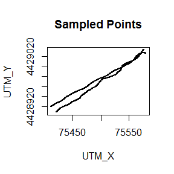

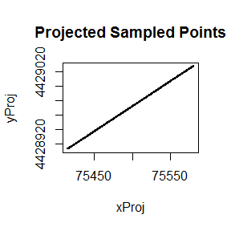

```r
coords <- planform[transectName=="t3", list(UTM_X, UTM_Y),]
linmod <- lm(coords$UTM_Y~coords$UTM_X)
proj.coords <- ortho.proj(coords$UTM_X, coords$UTM_Y, linmod$coefficients[2],
                          linmod$coefficients[1])
plot(coords, main="Sampled Points", pch=20, cex=0.5)
plot(proj.coords, main="Projected Sampled Points", pch=20, cex=0.5)
```

This process is simplified with `project.transect` discussed in the “Projecting transects” section.

### Projecting transects

Because only one transect can be processed at a time with `ortho.proj`, projecting transects with `ortho.proj` can be tedious. Additionally, `ortho.proj` requires some pre-existing knowledge on the slope and intercept parameters of a transect, which are likely only know with additional processing. However, `project.transect` allows multiple transects to be projected at once and does not require any pre-existing knowledge of intercept or slope (it does this by automating some of the steps in the example above). `project.transect` does however, require the transect to be identified for every sample point supplied to the function, if the transects are not identified, all sample points are assumed to come from the same transect.

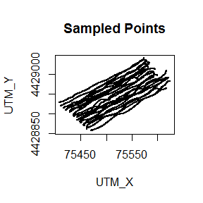

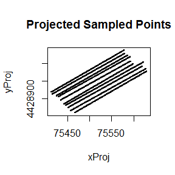

```r
tran.coords <- planform[, list(UTM_X, UTM_Y, transectName),]
proj.tran <- project.transect(planform$UTM_X, planform$UTM_Y, planform$transectName)
plot(UTM_Y~UTM_X, tran.coords, main="Sampled Points", pch=20, cex=0.5)
plot(yProj~xProj, proj.tran, main="Projected Sampled Points", pch=20, cex=0.5)
```

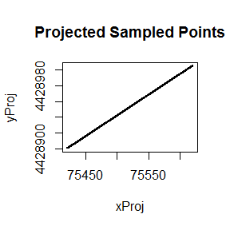

```r
tran.coords <- planform[, list(UTM_X, UTM_Y),]
proj.tran <- project.transect(planform$UTM_X, planform$UTM_Y)
plot(yProj~xProj, proj.tran, main="Projected Sampled Points", pch=20, cex=0.5)
```

### Determine the heading of a transect

The compass heading of a transect relative to flow (from river right to river left) can be determined with `transectHeading`. This function takes x and y coordinates of points along a transect and determines the heading based on the distance travelled in the x and y directions. The flow heading is then used to determine the river right and left ends of the transect and the heading is adjusted to reflect a transect progressing from river right to left. Flow heading can either be provided (if known) or velocities and depth at each sample point can be supplied to `transectHeading` in lieu of flow heading. When depth and velocities are supplied to `transectHeading`, velocity vectors are weighted by depth (to account for area sampled) and the mean cross-section flow direction is calculated. This procedure assumes the depth- or layer-averaged velocities of an ensemble are supplied to `transectHeading`. If velocities of individual cells are supplied, supplying cell height instead of water depth is more appropriate.

```r
#Determine transect heading from planform data
planform.t3 <- planform.ADCP[transectName=="t3",,]
transectHeading(planform.t3$UTM_X_Proj, planform.t3$UTM_Y_Proj, planform.t3$Mean.Vel.E,
                planform.t3$Mean.Vel.N, planform.t3$depth)
```

```
## [1] 55.1364
```

```r
#Determine transect heading from cross-section data
secondary.t3 <- secondary.ADCP[transectName=="t3",,]
transectHeading(secondary.t3$UTM_X_Proj, secondary.t3$UTM_Y_Proj, secondary.t3$Mean.Vel.E,
                secondary.t3$Mean.Vel.N, secondary.t3$cellHeight)
```

```
## [1] 55.13583
```

### Determining flow heading

The compass heading of two velocity vectors can be determined with `heading`. If the velocity vectors are of velocities to east and north, `heading` will return compass heading in degrees, of those vectors.

```r
easting <- c(0,1,1,1,0,-1,-1,-1)
northing <- c(1,1,0,-1,-1,-1,0,1)
heading(easting, northing)
```

```
## [1]   0  45  90 135 180 225 270 315
```

Although `heading` is set-up to output compass heading, the arithmetic heading of two vectors can also be calculated by supplying the east and north or x and y vectors in reverse order.

```r
heading(northing, easting)
```

```
## [1]  90  45   0 315 270 225 180 135
```

### Calculating average velocity within a defined layer of the water column

The integrated mean of y within the defined bounds of x can be calculated with `layerAvg`. `layerAvg` requires a vector of y values, a sorted vector of x values, and the upper and lower bounds of x, which y is integrated over.

```r
x <- c(1:10)
y <- x^2
#Determine the mean value of y between 2 and 8.
layerAvg(x,y,2,8)
```

```
## [1] 28.16667
```

```r
#Application with ADCP data
#Determine the mean east velocity between the surface (0m) and 2 m depth
#Note that only one sample/ensemble can be processed at a time
ensembleOne <- secondary.t3[tDist==0,,]
ensembleOne <- ensembleOne[order(cellDepth),,]
layerAvg(ensembleOne$cellDepth, ensembleOne$Vel.E, 0, 2)
```

```
## [1] 0.4537948
```

### Make a color gradient

`jet.colors` is borrowed from the examples in `?colorRampPalette` and creates a blue to red color gradient. This is the default color gradient used by `plot.xSec` and `plot.planform`. See `colorRampPalette` for additional details. Black and white color gradients are also available with the `black.white` and `white.black` functions, which create a black to white and white to black gradient, respectively.

```r
jet.colors(10)
```

```
##  [1] "#00007F" "#0000F0" "#0062FF" "#00D4FF" "#46FFB7" "#B7FF46" "#FFD400"
##  [8] "#FF6200" "#F00000" "#7F0000"
```

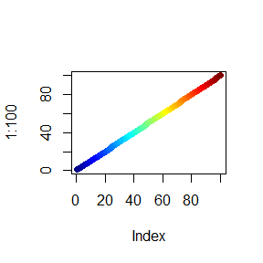

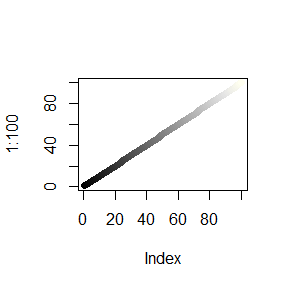

```r
plot(1:100, pch=19, col=jet.colors(100))
plot(1:100, pch=19, col=black.white(100))
```

## Package Info

U.S. Geological Survey (USGS) Computer Program rivSurveyR version 2.1. Written by Jason L. Fischer, USGS - Great Lakes Science Center, Ann Arbor, Michigan, USA. Written in programming language R (R Core Team, 2014, www.R-project.org), version 3.3.0 (2016-05-03). Run on a PC with Intel(R) Core(TM) i5 CPU, 2.40 GHz processor, 8.0 GB RAM, and Microsoft Windows 7 Enterprise operating system 2009 Service Pack 1. Source code is available from Jason L. Fischer on GitHub, jfischer@usgs.gov.

## Disclaimer

Although this program has been used by the USGS, no warranty, expressed or implied, is made by the USGS or the United States Government as to the accuracy and functioning of the program and related program material nor shall the fact of distribution constitute any such warranty, and no responsibility is assumed by the USGS in connection therewith. Use of trade names is strictly for informative purposes and does not imply endorsement by USGS.

## References

Cheng-Lung, 1991. “Unified Theory on Power Laws for Flow Resistance.” Journal of Hydraulic Engineering, Vol. 117, No. 3, March 1991, 371-389.

Czuba, J.A., Best, J.L., Oberg, K.A., Parsons, D.R., Jackson, P.R., Garcia, M.H., Ashmore, P., 2011. Bed morphology, flow structure, and sediment transport at the outlet of Lake Huron and in the upper St. Clair River. Journal of Great Lakes Research 37, 480-493.

Garcia, M.H., 2008. Sediment transport and morphodynamics, chap. 2. In: Garcia, M.H. (Ed.), Sedimentation Engineering: Processes, Measurements, Modeling, and Practice No. 110. American Society of Civil Engineers, Reston, Virginia, pp. 21-163.

Keulegan, G.H., 1938. Laws of turbulent flow in open channels. Journal of Research of the National Bureau Standards 21, 707-741.

Lane, S.N., Bradbrook, K.F., Richards, K.S., Biron, P.M., Roy, A.G., 2000. Secondary circulation cells in river channel confluences: Measurement artefacts or coherent flow structures? Hydrological Processes 14, 2047-2071.

Mueller, D.S., Wagner, C.R., Rehmel, M.S., Oberg, K.A,, Rainville, F., 2013. Measuring discharge with acoustic Doppler current profilers from a moving boat (ver. 2.0, December 2013): U.S. Geological Survey Techniques and Methods, book 3, chap. A22, 95p.

Parsons, D.R., Jackson, P.R., Czuba, J.A., Engel, F.L., Rhoads, B.L., Oberg, K.A., Best, J.L., Mueller, D.S., Johnson, K.K., Riley, J.D., 2013. Velocity mapping toolbox (VMT): A processing and visualization suite for moving-vessel ADCP measurements. Earth Surface Processes and Landforms 38, 1244-1260.

Rhoads, B.L., Kenworthy, S.T., 1998. Time-averaged flow structure in the central region of a stream confluence. Earth Surface Processes and Landforms 23, 171-191.

Simpson, M.R., Oltmann, R.N., 1990. “An Acoustic Doppler Discharge Measurement System.” Proceedings of the 1990 National Conference on Hydraulic Engineering, Vol. 2, 903-908.

Szupiany, R.N., Amsler, M.L., Best, J.L., Parsons, D.R., 2007. Comparison of fixed- and moving-vessel flow measurements with aDp in large a river. Journal of Hydraulic Engineering 133, 1299-1309.